```bash
RETICULATE_MINICONDA_ENABLED=FALSE
```

```python
import os
```

Assumptions of linear regression: 1- **Linearity**: The relationship between X and the mean of Y is linear. 2 **Homoscedasticity**: The variance of residual is the same for any value of X. 3- **Independence**: Observations are independent of each other. Let’s start with the built-in data set cars. cars data has 50 rows and two columns.

```r
setwd('/home/emre/fMRI/Codes_GH/DataScienceExamples')
#head(cars)
#str(cars)
#library(datarium) # The data database for R
```

## Load the data

```r
library(datarium)
head(marketing)
```

```
##   youtube facebook newspaper sales
## 1  276.12    45.36     83.04 26.52
## 2   53.40    47.16     54.12 12.48
## 3   20.64    55.08     83.16 11.16
## 4  181.80    49.56     70.20 22.20
## 5  216.96    12.96     70.08 15.48
## 6   10.44    58.68     90.00  8.64
```

The data has four columns of which three of them are independent variables, and called youtube, facebook and newspaper. They are related to marketing expenditure.

## Exploratory Data Analysis

### Scatter Plot

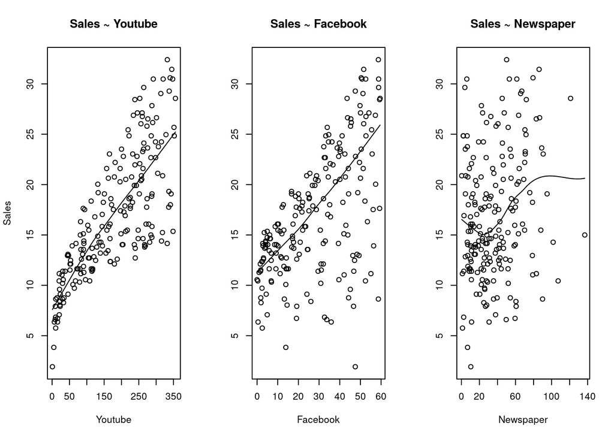

```r
#scatter.smooth(x=cars$speed, y=cars$dist, main="Dist ~ Speed",ylab = "Distance", xlab = "Speed")  # scatterplot
par(mfrow=c(1, 3))

scatter.smooth(x = marketing$youtube, y=marketing$sales, main="Sales ~ Youtube",xlab = "Youtube", ylab = "Sales")  # scatterplot
scatter.smooth(x = marketing$facebook, y=marketing$sales, main="Sales ~ Facebook",xlab = "Facebook", ylab = "")  # scatterplot
scatter.smooth(x = marketing$newspaper, y=marketing$sales, main="Sales ~ Newspaper",xlab = "Newspaper", ylab = "")  # scatterplot
```

```r
#pairs(marketing)
```

### Box plot

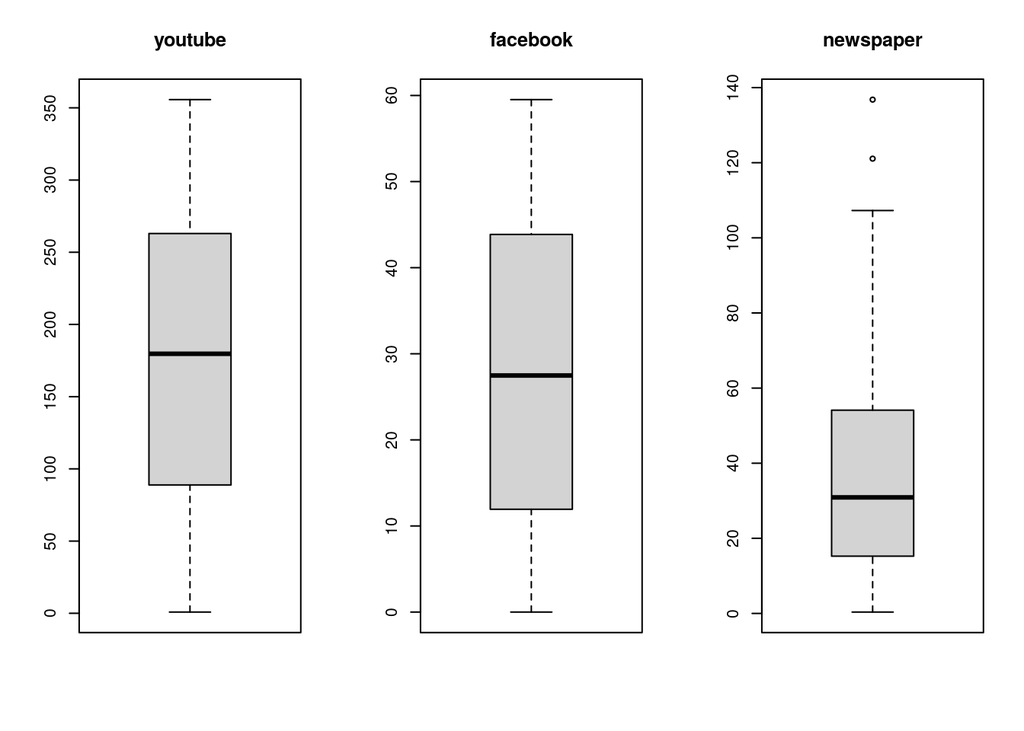

```r
par(mfrow=c(1, 3))  # divide graph area in 2 columns
boxplot(marketing$youtube, main="youtube")
boxplot(marketing$facebook, main="facebook")
boxplot(marketing$newspaper, main="newspaper")
```

```r
#boxplot(marketing$sales)
#boxplot(cars$dist, main="Distance", sub=paste("Outlier value: ", boxplot.stats(cars$dist)$out))  # box plot for 'distance'
```

Newspaper columns has two outliers. Outliers can be detected usinq quantiles.

IQR = 3rd Quantile - 1st Quantile

For a value of independent variable (x) if x > 3rd Quantile + 1.5*IQR or if x < 1st Quantile - 1.5*IQR then x is outlier.

```r
#summary(marketing[,-4])
```

The **FindOutliersIQR()** function calculates inter-quantile range (IQR) using built-in IQR function and quantiles using the built-in quantile function. It uses these values to detect and return outliers if any.

```r
FindOutliersIQR <- function(x)
{
  x.quantile <- quantile(x) # cal
  x.IQR <- IQR(x)
  upper <- x.quantile["75%"]  + 1.5 * x.IQR
  lower <- x.quantile["25%"]  - 1.5 * x.IQR

  return(x[x < lower | x > upper])
}

outliers <- sapply(marketing[,-4], FindOutliersIQR)

print(outliers)
```

```
## $youtube
## numeric(0)
##
## $facebook
## numeric(0)
##
## $newspaper
## [1] 136.80 121.08
```

Only newspaper columns have outlier values (136.8, 121.08) but we will ignore them right now.

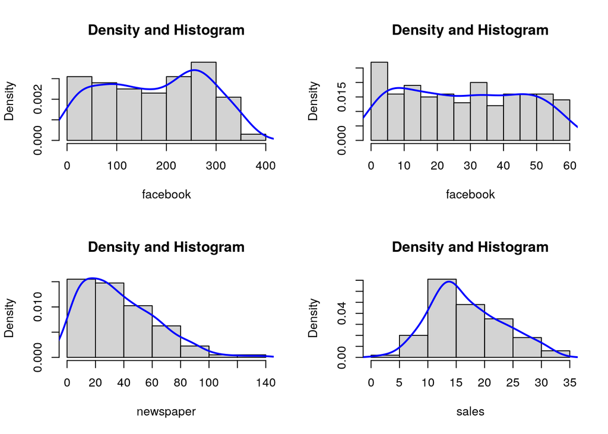

```r
# youtube
par(mfrow = c(2,2))
hist(marketing$youtube,
 border="black",
 prob = TRUE, # show densities instead of frequencies
 xlab = "facebook",
 main = "Density and Histogram")
lines(density(marketing$youtube), # density plot
 lwd = 2, # thickness of line
 col = "blue")

# facebook
hist(marketing$facebook,
 border="black",
 prob = TRUE, # show densities instead of frequencies
 xlab = "facebook",
 main = "Density and Histogram")
lines(density(marketing$facebook), # density plot
 lwd = 2, # thickness of line
 col = "blue")

# newspaper
hist(marketing$newspaper,
 border="black",
 prob = TRUE, # show densities instead of frequencies
 xlab = "newspaper",
 main = "Density and Histogram")
lines(density(marketing$newspaper), # density plot
 lwd = 2, # thickness of line
 col = "blue")

# newspaper
hist(marketing$sales,
 border="black",
 prob = TRUE, # show densities instead of frequencies
 xlab = "sales",
 main = "Density and Histogram")
lines(density(marketing$sales), # density plot
 lwd = 2, # thickness of line
 col = "blue")
```

Note that none of the independent variables distributions look like normal but remember that using linear models it does not have to. The residuals of the linear model should be distributed normally. That we will check after we fit the model.

## Linear Models with Ordinary Least Squares

In this section, we will see how to built basic linear models using **lm()** and report results using **summary()** functions parameters and statistics of the model. We will start with the simplest model. The dependent varaible is dependent only on intercept.

### Only Intercept Model

$$y = \beta_0 + \epsilon$$

As the first step we create a function that creates a line equation from estimated coefficients and intercept.

```r
lm_eq <- function(model, yname = 'y' ) {

  a = format(unname(coef(model)[1]), digits = 3)
  b = format(unname(coef(model)[2]), digits = 3)
  r2 = format(summary(model)$r.squared, digits = 3)
  cc <-  coef(model)
  eqn <- paste(yname," = ", paste(round(cc[1],2), paste(round(cc[-1],2), names(cc[-1]), sep=" * ", collapse=" + "), sep=" + "), " e")
  return(eqn)
  #return(paste0(yname, ' = ',a, ' + ', b,'*', xname,'\n','R^2 = ',r2))
}
```

Next we create our model with only intercept plot the line on the scatter plot.

```r
marketing.simple <- lm(marketing$sales ~ 1)
with(marketing,(plot(x = youtube, y = sales, xlab = "youtube", ylab = "Sales")))
```

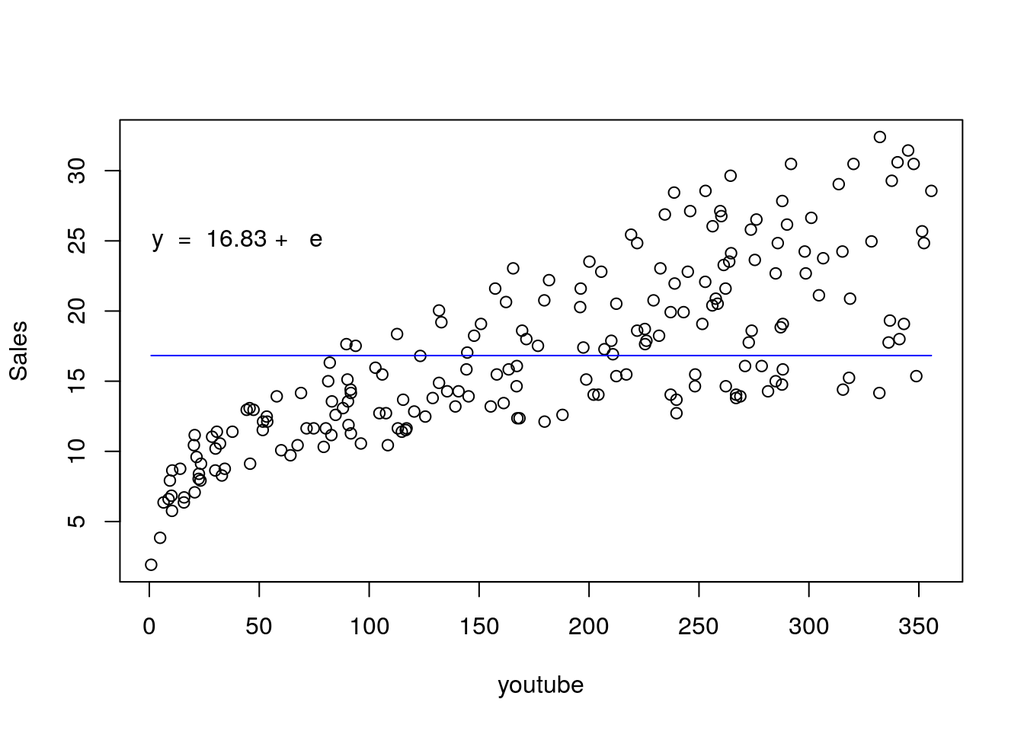

```r
lines(marketing$youtube,fitted(marketing.simple), col = "blue")
text(x=40, y = 25, labels=lm_eq(marketing.simple))
```

```r
marketing.simple.summary <- summary(marketing.simple)

marketing.simple.summary
```

```
##
## Call:
## lm(formula = marketing$sales ~ 1)
##
## Residuals:
##     Min      1Q  Median      3Q     Max
## -14.907  -4.377  -1.347   4.053  15.573
##
## Coefficients:
##             Estimate Std. Error t value Pr(>|t|)
## (Intercept)  16.8270     0.4427   38.01   <2e-16 ***
## ---
## Signif. codes:  0 '***' 0.001 '**' 0.01 '*' 0.05 '.' 0.1 ' ' 1
##
## Residual standard error: 6.261 on 199 degrees of freedom
```

## Comparison of Only intercept term to one sample t-test.

This could be done with one-sample t-test:

```r
print(t.test(x = marketing$sales))
```

```
##
##  One Sample t-test
##
## data:  marketing$sales
## t = 38.009, df = 199, p-value < 2.2e-16
## alternative hypothesis: true mean is not equal to 0
## 95 percent confidence interval:
##  15.95398 17.70002
## sample estimates:
## mean of x
##    16.827
```

```r
print(summary(marketing.simple) )
```

```
##
## Call:
## lm(formula = marketing$sales ~ 1)
##
## Residuals:
##     Min      1Q  Median      3Q     Max
## -14.907  -4.377  -1.347   4.053  15.573
##
## Coefficients:
##             Estimate Std. Error t value Pr(>|t|)
## (Intercept)  16.8270     0.4427   38.01   <2e-16 ***
## ---
## Signif. codes:  0 '***' 0.001 '**' 0.01 '*' 0.05 '.' 0.1 ' ' 1
##
## Residual standard error: 6.261 on 199 degrees of freedom
```

## Linear Model with only one dependent variable

The linear model for one exploratory variable is:

$$y_i = \beta_{0i} + \beta_{1i}x$$
In our example:

$$Distance = \beta_0 + \beta_1 * Speed$$

To see, if we want to check if there is a linear relation between two variables, then we should check the slope of the model $\beta_1$ should be different then zero. So our hypothesis is:

$H_0 :\beta_1 = 0$

$H_1 :\beta_1 \neq 0$

First step is to fit the model and check the results by printing the model:

```r
cars.lm <- lm(dist ~ speed, data=cars)
print(cars.lm)
```

```
##
## Call:
## lm(formula = dist ~ speed, data = cars)
##
## Coefficients:
## (Intercept)        speed
##     -17.579        3.932
```

```r
marketing.lm.1 <- lm(sales ~ youtube , data=marketing)
summary.marketing.lm.1 <- summary(marketing.lm.1)

summary.marketing.lm.1$r.squared
```

```
## [1] 0.6118751
```

```r
#plot(marketing.lm.1)
```

When we check the coefficients of the model we see that our estimated fit is:
$$Sales = 8.4 + 0.048 * Youtube$$

Similarly as we did on previous section, we can visualise the fit on the scatter plot.

```r
with(marketing,(plot(x = youtube, y = sales,xlab = "Youtube", ylab = "Sales")))
```

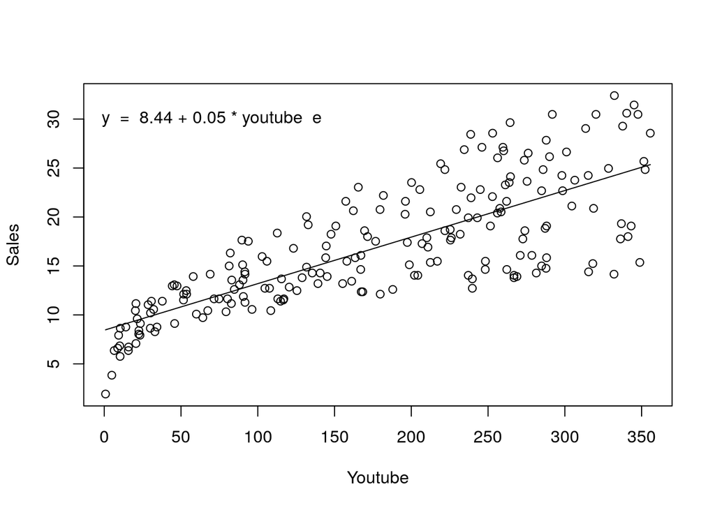

```r
lines(marketing$youtube,fitted(marketing.lm.1))
text(x=70, y = 30, labels=lm_eq(marketing.lm.1))
```

```r
marketing.lm.1.summary <- summary(marketing.lm.1)
#marketing.lm.sd <- sqrt(deviance(marketing.lm.1) / df.residual(marketing.lm.1))

marketing.lm.1.coef <- marketing.lm.1.summary$coefficients

marketing.lm.1.beta.estimate <- marketing.lm.1.coef["youtube", "Estimate"]  # get beta estimate for speed
marketing.lm.1.se <- marketing.lm.1.coef["youtube", "Std. Error"]  # get std.error for speed

t_value <- marketing.lm.1.summary$coefficients["youtube","t value"]
p_value <- marketing.lm.1.summary$coefficients["youtube","Pr(>|t|)"]

t_value <- marketing.lm.1.beta.estimate/marketing.lm.1.se  # calc t statistic
p_value <- 2*pt(-abs(t_value), df=nrow(cars)-ncol(cars))
```

Then t value of the coefficient estimate of the youtube effect is:

$t_{youtube}$ = 17.67

```r
f <- marketing.lm.1.summary$fstatistic  # parameters for model p-value calc
model_p <- pf(f[1], f[2], f[3], lower=FALSE)
print(model_p)
```

```
##       value
## 1.46739e-42
```

```r
marketing.lm.2 <- lm(sales ~ youtube + facebook , data=marketing)
summary.marketing.lm.2 <- summary(marketing.lm.2)
```

# Model Evaluation

## $R^2$ and $R^2_{adjusted}$

When the model assumptions for linear model is met then either $R^2$ or $R^2_{adjusted}$ can be used to measure goodness-of-fit Remember sum of squares (SSE) is:
$$SSE = \sum_i{(y_i - \hat{y_i})^2}{}$$
where $y_i$ is each data and $\hat{y}_i$ is the model value. And total sum of squares (SST) is :
$$SST = \sum_i{(y_i - {\bar{y_i}})^2}{}$$
SST is basically variance of the data and SSE is the variance of the residuals (unexplained). Then $R^2$ is the explained variance to total variance of the data. The closer the $R^2$ to 1 is better.
$$R^2 = 1 - \frac{SSE}{SST}$$
$R^2$ value can be obtained from the summary of the model :

```r
marketing.lm.1.summary$r.squared
```

```
## [1] 0.6118751
```

## Model fitting using linear algebra (optional)

Reference 1: http://r-statistics.co/Linear-Regression.html basic examples Reference 2: From Faraday linear models with R linear algebra calculations Reference 3: https://www.r-bloggers.com/2012/09/histogram-density-plot-combo-in-r/ histograms Reference 4: https://www.r-graph-gallery.com/44-polynomial-curve-fitting.html

```r
#sd <- sqrt(crossprod(cars.lm.summary$residuals,cars.lm.summary$residuals)/48)
```

## Solve using QR decomposition

QR decomposition is a more stable method to solve equation.

## Sandwich Models and OLS

http://www.sthda.com/english/articles/40-regression-analysis/167-simple-linear-regression-in-r/